# Sampling Distributions and Order Statistics

Ashik E Elahi

2024-11-17

##### Problem: 1 - Suppose X follows a normal distribution with mean $\mu$ and variance $\sigma^2$.

##### (i) Plot the distributions on a graph paper separately with ($\mu = 3, \sigma^2 = 16), (\mu = 5, \sigma^2 = 16)$, and ($\mu = 7, \sigma^2 = 16$) and compare the graphs.

##### (ii) Plot the distributions on same graph paper with ($\mu = 4, \sigma^2 = 4), (\mu = 4, \sigma^2 = 9)$, and ($\mu = 4, \sigma^2 = 16)$

##### Solution 1 (i):

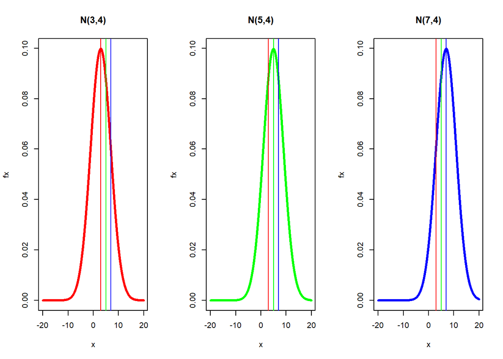

```r
par(mfrow = c(1, 3))
mu <- c(3, 5, 7)
sigma <- c(4, 4, 4)
colors <- c("red", "green", "blue")
labels <- c("N(3,4)", "N(5,4)", "N(7,4)")
x <- seq(-20, 20, 0.01)

for(i in 1:3) {
  fx <- dnorm(x, mean = mu[i], sd = sigma[i])
  plot(x, fx, type="l", col = colors[i], lwd=3, main = labels[i])

  abline(v = mu, col = colors)
}
```

##### Solution 1 (ii):

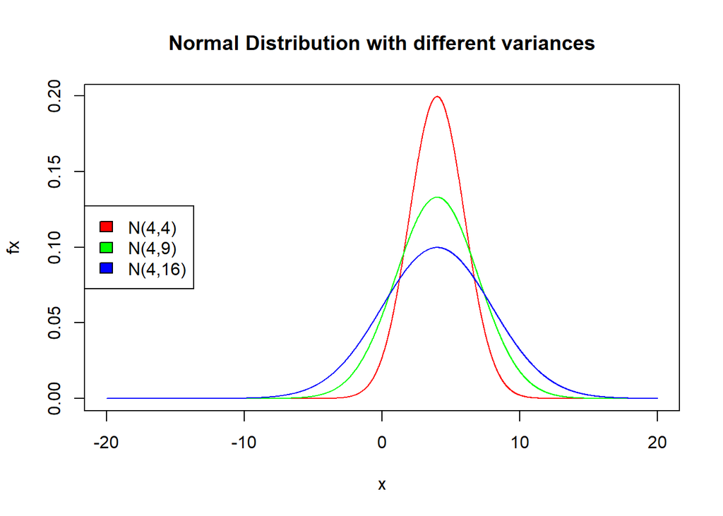

```r
par(mfrow = c(1, 1))
mu <- c(4, 4, 4)
sigma <- c(2, 3, 4)
colors <- c("red", "green", "blue")
labels <- c("N(4,4)", "N(4,9)", "N(4,16)")
x <- seq(-20, 20, 0.01)

for(i in 1:3) {
  fx <- dnorm(x, mean = mu[i], sd = sigma[i])
  if(i==1) {
    plot(x, fx, type="l", col = colors[i], main="Normal Distribution with different variances")
  } else {
    lines(x, fx, col = colors[i])
  }
}
legend("left", labels, fill=colors)
```

##### Problem 2: Generate 1200 random samples of size n = 12 with $\mu = 4$ and $\sigma^2 = 9$. Suppose $s^2=\frac{1}{n-1}\sum_i^n (x_i - \bar{x})^2$. Using suitable graph, justify that $\frac{(n-1)s^2}{\sigma^2}$ follows a chi-square distribution with (n-1) degress of freedom.

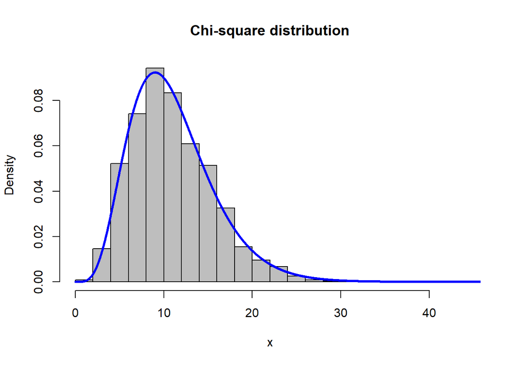

```r
set.seed(11)
n = 12
mu = 4
sigma = sqrt(9)
it = 1200

xvar = array()
for(i in 1:it) {
  x = rnorm(n, mu, sigma)
  xvar[i] = var(x)
}
# xvar -> list of variances

x = ((n-1)*xvar)/sigma^2
hist(x, breaks = 15, freq = F, col = "gray", main="Chi-square distribution")

x = seq(0,120, 0.01)
chisq.pdf = dchisq(x, df=n-1)
lines(x, chisq.pdf, col="blue", lwd=3)
```

##### Problem 3: A random sample of size 4 is drawn from a population that has a uniform distribution on the interval (0, 5). The resulting order statistics are $X_{1:4}, X_{2:4}, X_{3:4}$ and $X_{4:4}$. Determine the cumulative distribution function (CDF) of the $3^{rd}$ order statistic $(X_{3:4})$ and plot the CDF of the $3^{rd}$ order statistic. Evaluate the probability $P[X_{3:4} \geq 2]$

```r
Fr_n = function(x, r, n, a, b) {
  cdf_x = punif(x, min = a, max = b)
  sum_value = 0
  for(j in r:n) {
    sum_value = sum_value + choose(n, j) * cdf_x^j * (1-cdf_x)^(n-j)
  }
  return(sum_value)
}

Fr_n_eqn = function(x, r, n) {
  eqn = ""
  for(j in r:n) {
    term = paste0("(", n, "C", j, ")*F(x)^", j, "*[1-F(x)]^", n-j)
    if(j < n) {
      eqn = paste0(eqn, term, " + ")
    } else {
      eqn = paste0(eqn, term)
    }
  }
  return(eqn)
}

r = 3
n = 4
a = 0
b = 5
x = seq(a, b, length.out = 100)

paste0("CDF of rth order statistic:", Fr_n_eqn(x, r, n))
```

```
## [1] "CDF of rth order statistic:(4C3)*F(x)^3*[1-F(x)]^1 + (4C4)*F(x)^4*[1-F(x)]^0"
```

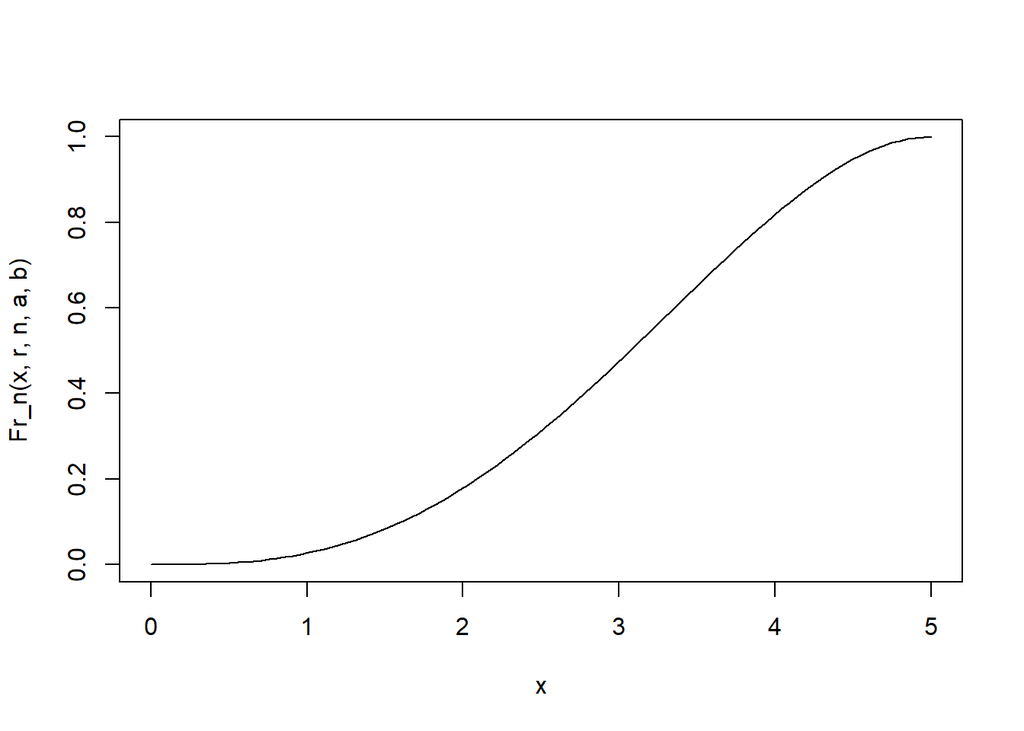

```r
plot(x, Fr_n(x, r, n, a, b), type="l")
```

```r
1 - Fr_n(x = 2, r, n, a, b)
```

```
## [1] 0.8208
```

##### Problem 4: A random sampe of size 7 us drawn fom a population that has a uniform distribution on the interval (0,5). The resulting order statistics are $X_{1:7}, X_{2:7}, X_{3:7}, X_{4:7}, X_{5:7}, X_{6:7}$ and $X_{7:7}$. Determine the PDF, mean and variance of 4th order (median) statistic. Also find mean an variance of smallest and largest order statistics.

```r
fr_n = function(x, r, n, a, b) {
  pdf_x = dunif(x, min=a, max=b)
  cdf_x = punif(x, min=a, max=b)
  numerator = factorial(n)/(factorial(r-1)*factorial(n-r))

  prob_dist = numerator*cdf_x^(r-1)*(1-cdf_x)^(n-r)*pdf_x
  return(prob_dist)
}

fr_n_eqn = function(r, n) {
  numerator = factorial(n) / (factorial(r-1)*factorial(n-r))
  prob_eqn = paste0(numerator, " F(x)^", r-1, " * [1 - F(x)]^", n-r, " * f(x)")
  return(prob_eqn)
}

moment_k = function(k, r, n, a, b){
  integrand = function(x) x^k * fr_n(x, r, n, a, b)
  moment = integrate(integrand, a, b)$value

  return(moment)
}

n = 7
r = 4
a = 0
b = 5
x = seq(a, b, length.out = 100)

paste0("PDF:", fr_n_eqn(r, n))
```

```
## [1] "PDF:140 F(x)^3 * [1 - F(x)]^3 * f(x)"
```

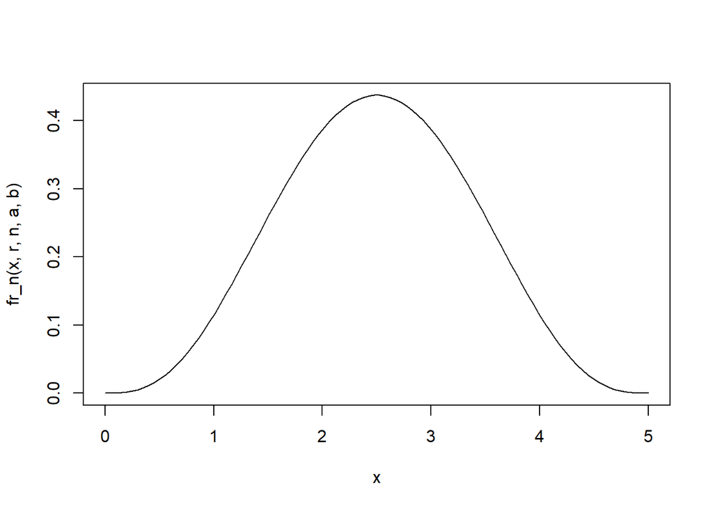

```r
plot(x, fr_n(x, r, n, a, b), type="l")
```

```r
mean_median = moment_k(k=1, r, n, a, b)
var_median = moment_k(k=2, r, n, a, b) - mean_median^2

paste0("For Median, Mean = ", mean_median, " and variance = ", var_median)
```

```
## [1] "For Median, Mean = 2.5 and variance = 0.694444444444445"
```

```r
mean_x1_n = moment_k(k=1, r=1, n, a, b)
var_x1_n = moment_k(k=2, r=1, n, a, b) - mean_x1_n^2
paste0("For smallest, Mean = ", mean_x1_n, " and variance = ", var_x1_n)
```

```
## [1] "For smallest, Mean = 0.625 and variance = 0.303819444444444"
```

```r
mean_xn_n = moment_k(k=1, r=n, n, a, b)
var_xn_n = moment_k(k=2, r=n, n, a, b) - mean_x1_n^2
paste0("For largest, Mean = ", mean_xn_n, " and variance = ", var_xn_n)
```

```
## [1] "For largest, Mean = 4.375 and variance = 19.0538194444444"
```

##### Problem 5: Suppose $X_{1:7} < X_{2:7} < X_{3:7} < X_{4:7} < X_{5:7} < X_{6:7} < X_{7:7}$ denote the order statistic based on a random sample of size 7 from the distribution having probability density function (pdf) $f(x) = \frac{1}{10}, 0 \leq x \leq 10$. Evaluate the mean and variance of the $5^{th}$ order statistic $(X_{5:7})$ and plot the CDF of the $5^{th}$ order statistic.

```r
fr_n = function(x, r, n, a, b) {
  pdf_x = dunif(x, min=a, max=b)
  cdf_x = punif(x, min=a, max=b)
  numerator = factorial(n)/(factorial(r-1)*factorial(n-r))

  prob_dist = numerator*cdf_x^(r-1)*(1-cdf_x)^(n-r)*pdf_x
  return(prob_dist)
}

moment_k = function(k, r, n, a, b){
  integrand = function(x) x^k * fr_n(x, r, n, a, b)
  moment = integrate(integrand, a, b)$value

  return(moment)
}

Fr_n = function(x, r, n, a, b) {
  cdf_x = punif(x, min = a, max = b)
  sum_value = 0
  for(j in r:n) {
    sum_value = sum_value + choose(n, j) * cdf_x^j * (1-cdf_x)^(n-j)
  }
  return(sum_value)
}


r = 5
n = 7
a = 0
b = 10
x = seq(a, b, length.out = 100)

mean_x5_n = moment_k(k = 1, r, n, a, b)
var_x5_n = moment_k(k = 2, r, n, a, b) - mean_x5_n^2

paste0("Mean = ", mean_x5_n, " and variance = ", var_x5_n)
```

```
## [1] "Mean = 6.25 and variance = 2.60416666666667"
```

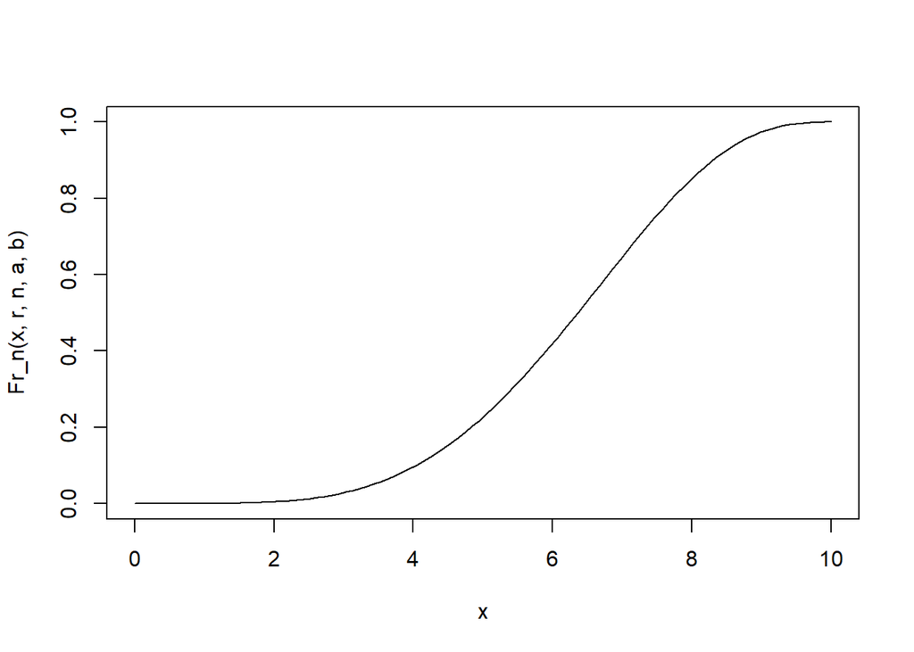

```r
plot(x, Fr_n(x, r, n, a, b), type = "l")
```

##### Problem 6: A random sample of size 3 is drawn from a population that has a uniform distribution on the interval (0, 1). The resulting order statistics are $X_{1:3}, X_{2:3}$ and $X_{3:3}$. Determine the mean and variance of smallest and largest order statistic.

```r
fr_n = function(x, r, n, a, b) {
  pdf_x = dunif(x, min=a, max=b)
  cdf_x = punif(x, min=a, max=b)
  numerator = factorial(n)/(factorial(r-1)*factorial(n-r))

  prob_dist = numerator*cdf_x^(r-1)*(1-cdf_x)^(n-r)*pdf_x
  return(prob_dist)
}


moment_k = function(k, r, n, a, b){
  integrand = function(x) x^k * fr_n(x, r, n, a, b)
  moment = integrate(integrand, a, b)$value

  return(moment)
}

n = 3
a = 0
b = 1
x = seq(a, b, length.out = 100)

mean_x1_n = moment_k(k=1, r=1, n, a, b)
var_x1_n = moment_k(k = 2, r=1, n, a, b) - mean_x1_n^2

paste0("For smallest, Mean = ", mean_x1_n, " and variance = ", var_x1_n)
```

```
## [1] "For smallest, Mean = 0.25 and variance = 0.0375"
```

```r
mean_xn_n = moment_k(k=1, r=n, n, a, b)
var_xn_n = moment_k(k = 2, r=n, n, a, b) - mean_xn_n^2
paste0("For largest, Mean = ", mean_xn_n, " and variance = ", var_xn_n)
```

```
## [1] "For largest, Mean = 0.75 and variance = 0.0375000000000001"
```

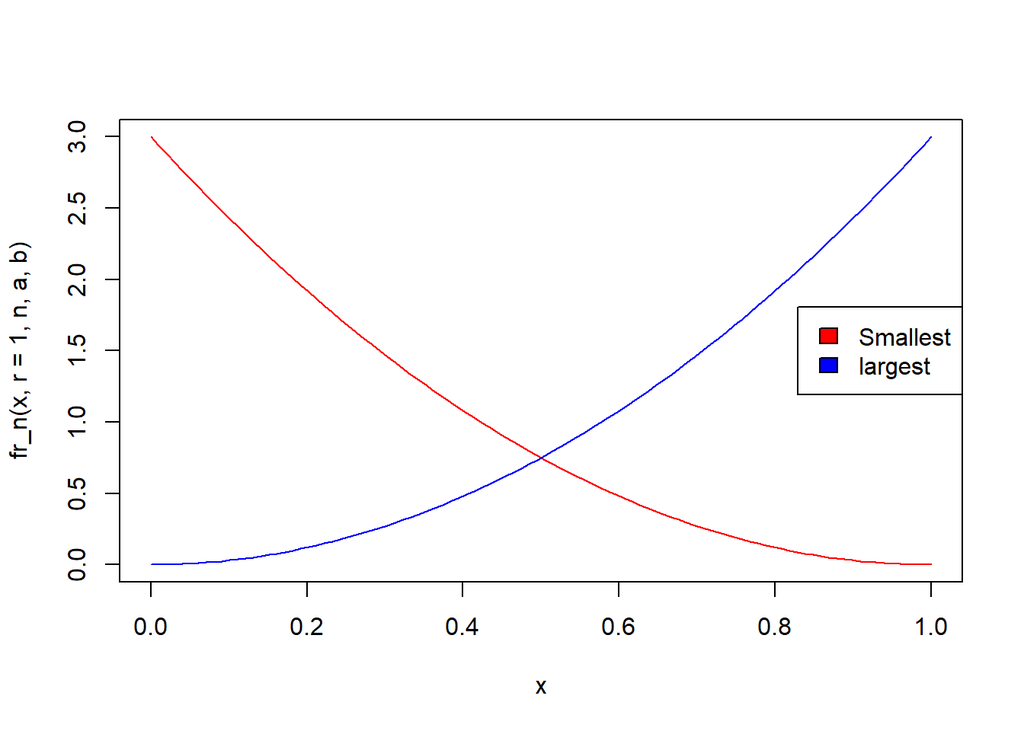

```r
plot(x, fr_n(x, r=1, n, a, b), type="l", col="red")
lines(x, fr_n(x, r=n, n, a, b), col="blue")

legend("right", c("Smallest", "largest"), fill = c("red", "blue"))
```

##### Problem 7: The random sample $X_1, X_2, ..., X_9$ of size 9 is drawn from a population that has a uniform distribution with the interval (0, 10). Evaluate the mean and variance of 7th order statistic.

```r
fr_n = function(x, r, n, a, b) {
  pdf_x = dunif(x, min=a, max=b)
  cdf_x = punif(x, min=a, max=b)
  numerator = factorial(n)/(factorial(r-1)*factorial(n-r))

  prob_dist = numerator*cdf_x^(r-1)*(1-cdf_x)^(n-r)*pdf_x
  return(prob_dist)
}

moment_k = function(k, r, n, a, b){
  integrand = function(x) x^k * fr_n(x, r, n, a, b)
  moment = integrate(integrand, a, b)$value

  return(moment)
}

n = 9
r = 7
a = 0
b = 10
x = seq(a, b, length.out = 100)

mean_x7_n = moment_k(k = 1, r, n, a, b)
var_x7_n = moment_k(k = 2, r, n, a, b) - mean_x7_n^2

paste0("Mean = ", mean_x7_n, " and variance = ", var_x7_n)
```

```
## [1] "Mean = 7 and variance = 1.90909090909091"
```

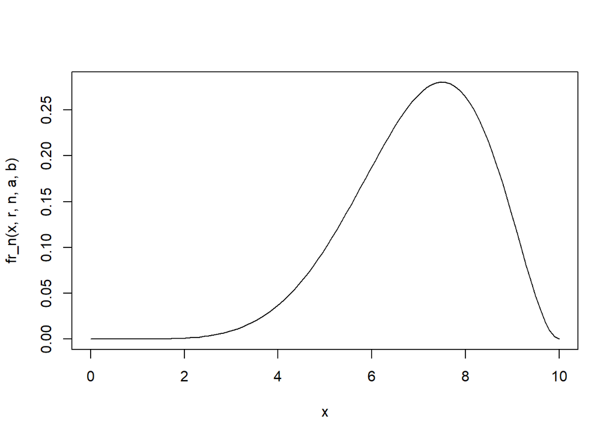

```r
plot(x, fr_n(x, r, n, a, b), type="l")
```

##### Problem 8: A random sample of size 3 is drawn from a population that has a uniform distribution on the interval (0, 1). The resulting order statistics are $X_{1:3}, X_{2:3}, X_{3:3}$. Determine the mean and variance of sample range.

```r
fr_n = function(x, r, n, a, b) {
  pdf_x = dunif(x, min=a, max=b)
  cdf_x = punif(x, min=a, max=b)
  numerator = factorial(n)/(factorial(r-1)*factorial(n-r))

  prob_dist = numerator*cdf_x^(r-1)*(1-cdf_x)^(n-r)*pdf_x
  return(prob_dist)
}

moment_k = function(k, r, n, a, b){
  integrand = function(x) x^k * fr_n(x, r, n, a, b)
  moment = integrate(integrand, a, b)$value

  return(moment)
}



exp_xy = function(n, a, b) {
  integrand = function(x) {
    f_y = function(y) x * y * n * (n-1) * (y-x)
    integrate(Vectorize(f_y), lower = x, upper =b)$value
  }
  moment = integrate(Vectorize(integrand), a, b)$value
  return(moment)
}

n = 3
a = 0
b = 1
x = seq(a, b, length.out = 100)

mean_x1_n = moment_k(k=1, r=1, n, a, b)
var_x1_n = moment_k(k=2, r=1, n, a, b) - mean_x1_n^2

mean_xn_n = moment_k(k=1, r=n, n, a, b)
var_xn_n = moment_k(k=2, r=n, n, a, b) - mean_xn_n^2


mean_sample_range = mean_xn_n - mean_x1_n

cov_x1_xn = exp_xy(n, a, b) - mean_xn_n * mean_x1_n

var_sample_range = var_xn_n + var_x1_n - 2*cov_x1_xn

paste0("For sample range, Mean = ", mean_sample_range , " and variance = ", var_sample_range)
```

```
## [1] "For sample range, Mean = 0.5 and variance = 0.0500000000000001"
```

#### Binomial Distribution: Suppose X follows a Binomial distribution with three different sets of parameters: n = 9 and p={0.55,0.35,0.4}. Plot the distributions on a graph paper separately.

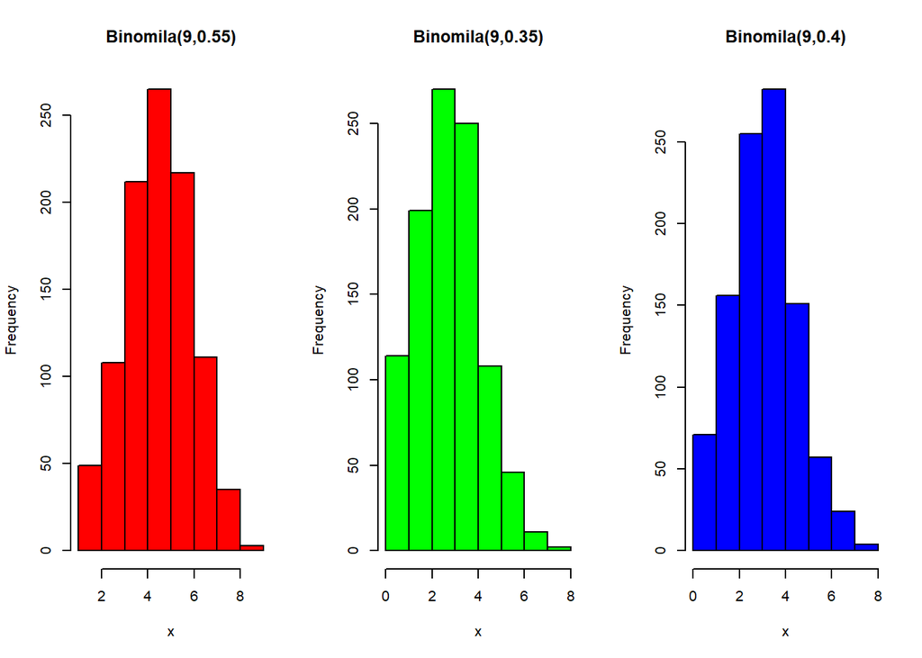

```r
set.seed(11)
par(mfrow=c(1, 3))
n = c(9, 9, 9) # size
p = c(0.55, 0.35, 0.4) # Probability
color = c("red", "green", "blue")
labels = c("Binomila(9,0.55)", "Binomila(9,0.35)", "Binomila(9,0.4)")
for(i in 1:3) {
 x = rbinom(1000, n[i], p[i])
 hist(x, col=color[i],  main = labels[i])
}
```

#### Poisson Distribution: Suppose X follows a Poisson distribution with three different values of the rate of parameter λ = {3, 5, 9}. Plot the distributions on a graph paper separately.

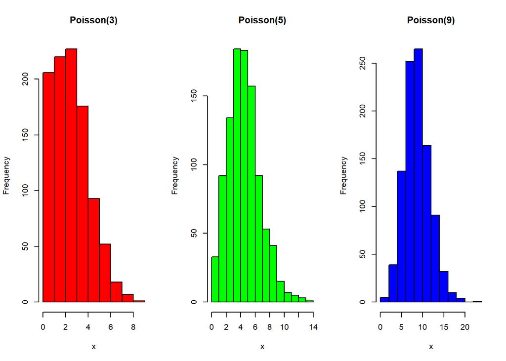

```r
set.seed(12)
par(mfrow=c(1,3))
p = c(3,5,9)
color = c("red", "green", "blue")
labels = c("Poisson(3)", "Poisson(5)", "Poisson(9)")
for(i in 1:3) {
 x = rpois(1000, p[i])
 hist(x, col=color[i], main=labels[i])
}
```